# Jonatan Peguero Assignment 1

```python
%%capture
#capture hides the output
!pip install wooldridge
```

```python
import numpy as np
import pandas as pd
import wooldridge as woo
```

### Question 1A: How many observations are in this data set

```python
fert = woo.dataWoo("fertil2")
observations = fert.shape[0]
print(f'Number of Observations: {observations}')
```

```
Number of Observations: 4361
```

### Question 1B: Describe the variable "yearborn". Show the average level of education for those born in the year on the 25% and 75% percentile

```python
display(fert['yearborn'].describe())
percent25 = fert[fert['yearborn']==fert['yearborn'].quantile(0.25)]['educ'].mean()
percent75 = fert[fert['yearborn']==fert['yearborn'].quantile(0.75)]['educ'].mean()
print(f'Average level of education in the 25th percentile: {percent25:.2f}')
print(f'Average level of education in the 75th percentile: {percent75:.2f}')
```

```
count    4361.000000
mean       60.433616
std         8.682723
min        38.000000
25%        55.000000
50%        62.000000
75%        68.000000
max        73.000000
Name: yearborn, dtype: float64
```

```
Average level of education in the 25th percentile: 4.38
Average level of education in the 75th percentile: 7.07
```

### Question 1C: Find the maximum number of children for households with TV in these data.

```python
max_children_with_tv = fert[fert['tv'] == 1]['children'].max()
print(f'The max amount of children within a single household that has a tv is: {max_children_with_tv}')
```

```
The max amount of children within a single household that has a tv is: 9
```

### Question 1D: Create a table where you present the average education and age at first birth by knowledge of birth control methods. What can you say about these results?

```python
display(fert[["educ", "agefbrth", "knowmeth"]].describe())
#crostab = pd.crosstab(fert[fert["knowmeth"]==1]['educ'], fert[fert["knowmeth"]==1]['age'])
#display(crostab)
pd.pivot_table(fert, values=["educ", "agefbrth"], index="knowmeth",aggfunc = np.mean)
```

|  | educ | agefbrth | knowmeth |
| --- | --- | --- | --- |
| count | 4361.000000 | 3273.000000 | 4354.000000 |
| mean | 5.855996 | 19.011305 | 0.963252 |
| std | 3.927075 | 3.092333 | 0.188164 |
| min | 0.000000 | 10.000000 | 0.000000 |
| 25% | 3.000000 | 17.000000 | 1.000000 |
| 50% | 7.000000 | 19.000000 | 1.000000 |
| 75% | 8.000000 | 20.000000 | 1.000000 |
| max | 20.000000 | 38.000000 | 1.000000 |

| knowmeth | agefbrth | educ |
| --- | --- | --- |
| 0.0 | 19.913043 | 2.487500 |
| 1.0 | 18.984877 | 5.994278 |

### Conclusion:

From the pivot table, we are able to conclude that the average age of females that gave birth for the first time that know about birth control methods are lower than those who did not know about birth control methods and also gave birth for the first time. Also, we can see that of those females that did not know about birth control mehtods, they tend to have less years of education compared to those who did know about birth control methods

### Question 2A: Find the correlation between math4, read4, lunch, and exppp. (Make a matrix and use a colored matrix like in the handout) What do you conclude?

|  | math4 | read4 | lunch | exppp |
| --- | --- | --- | --- | --- |
| math4 | 1.000 | 0.843 | -0.597 | -0.031 |
| read4 | 0.843 | 1.000 | -0.611 | -0.031 |
| lunch | -0.597 | -0.611 | 1.000 | 0.233 |
| exppp | -0.031 | -0.031 | 0.233 | 1.000 |

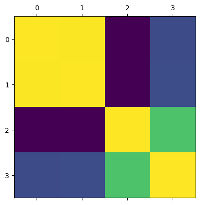

```python
import matplotlib.pyplot as plt
import seaborn as sns
meap = woo.dataWoo("meap01")
correlation = meap[['math4','read4','lunch','exppp']].corr().round(3)
display(correlation)
plt.matshow(correlation.corr())
plt.show()
```

### Analysis:

From this clored matrix, we can conclude that there is a positive correlation between math4 with itself, read4 and itself, and with each other. There is also a positive correlation between lunch with itself, exppp with itself, and with each other. Any other combination of those variables have a negative correlation.

### Question 2B: Find the largest and smallest values of math4 and read4. Does the range make sense? Explain.

```python
mathMax = meap['math4'].max()
mathMin = meap['math4'].min()
readMax = meap['read4'].max()
readMin = meap['read4'].min()
print(f'{mathMax},{mathMin},{readMax},{readMin}')
```

```
100.0,0.0,100.0,0.0
```

### Explanation:

This range does not make sense because it is very rare for schools to have nobody pass the test. So 0 does not make sense, but 100 does make sense because some schools have everyone pass the test, although it is very rare.

### Question 2C: How many schools have a perfect pass rate on the math test? What percentage is this of the total sample of schools?

```python
perfect = meap[meap['math4'] == 100]
countperfect = perfect.shape[0]
schools = meap.shape[0]
percent_perfect = (countperfect / schools) * 100
print(f'The percent of schools that have a perfect pass rate on the math test is : {percent_perfect:.2f}%')
```

```
The percent of schools that have a perfect pass rate on the math test is : 2.08%
```

### Question 2D: How many schools have math pass rates of exactly 50%?

```python
half = meap[meap['math4'] == 50]
half_count = half.shape[0]
print(f' This many schools have a 50% pass rate on the math test: {half_count}')
```

```
 This many schools have a 50% pass rate on the math test: 17
```

### Question 2E: Find the average of exppp along with its standard deviation. Would you say there is a wide variation in per-pupil spending?

```python
expppAvg = meap['exppp'].mean()
expppStd = meap['exppp'].std()
print(f' The mean of expenditures per pupil is: {expppAvg:.2f} and the standard deviation of expenditures per pupil is: {expppStd:.2f}')
```

```
 The mean of expenditures per pupil is: 5194.87 and the standard deviation of expenditures per pupil is: 1091.89
```